# Predict Bike Sharing Demand with AutoGluon Template

## Step 4: Exploratory Data Analysis and Creating an additional feature

- Any additional feature will do, but a great suggestion would be to separate out the datetime into hour, day, or month parts.

```
array([[<Axes: title={'center': 'season'}>,
        <Axes: title={'center': 'holiday'}>,
        <Axes: title={'center': 'workingday'}>],
       [<Axes: title={'center': 'weather'}>,
        <Axes: title={'center': 'temp'}>,
        <Axes: title={'center': 'atemp'}>],
       [<Axes: title={'center': 'humidity'}>,
        <Axes: title={'center': 'windspeed'}>,
        <Axes: title={'center': 'casual'}>],
       [<Axes: title={'center': 'registered'}>,
        <Axes: title={'center': 'count'}>, <Axes: >]], dtype=object)
```

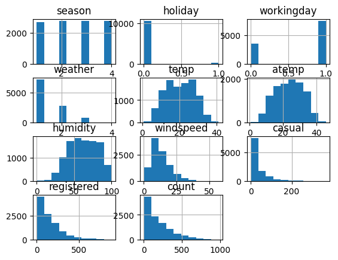

```python
# Create a histogram of all features to show the distribution of each one relative to the data. This is part of the exploritory data analysis
train.hist()
```

```python
# create a new feature
# convert datetime to datetime object
train['datetime'] = pd.to_datetime(train['datetime'])
test['datetime'] = pd.to_datetime(test['datetime'])


train["hour"] = train['datetime'].dt.hour
train["day"] = train['datetime'].dt.day
train["month"] = train['datetime'].dt.month
test["hour"] = test['datetime'].dt.hour
test["day"] = test['datetime'].dt.day
test["month"] = test['datetime'].dt.month
```

## Make category types for these so models know they are not just numbers

- AutoGluon originally sees these as ints, but in reality they are int representations of a category.
- Setting the dtype to category will classify these as categories in AutoGluon.

```python
train["season"] = train['season'].astype('category')
train["weather"] = train['weather'].astype('category')
test["season"] = test['season'].astype('category')
test["weather"] = test['weather'].astype('category')
```

```python
# View are new feature
train.head()
```

|  | datetime | season | holiday | workingday | weather | temp | atemp | humidity | windspeed | casual | registered | count | hour | day | month |
| --- | --- | --- | --- | --- | --- | --- | --- | --- | --- | --- | --- | --- | --- | --- | --- |
| 0 | 2011-01-01 00:00:00 | 1 | 0 | 0 | 1 | 9.84 | 14.395 | 81 | 0.0 | 3 | 13 | 16 | 0 | 1 | 1 |
| 1 | 2011-01-01 01:00:00 | 1 | 0 | 0 | 1 | 9.02 | 13.635 | 80 | 0.0 | 8 | 32 | 40 | 1 | 1 | 1 |
| 2 | 2011-01-01 02:00:00 | 1 | 0 | 0 | 1 | 9.02 | 13.635 | 80 | 0.0 | 5 | 27 | 32 | 2 | 1 | 1 |
| 3 | 2011-01-01 03:00:00 | 1 | 0 | 0 | 1 | 9.84 | 14.395 | 75 | 0.0 | 3 | 10 | 13 | 3 | 1 | 1 |
| 4 | 2011-01-01 04:00:00 | 1 | 0 | 0 | 1 | 9.84 | 14.395 | 75 | 0.0 | 0 | 1 | 1 | 4 | 1 | 1 |

```
array([[<Axes: title={'center': 'datetime'}>,
        <Axes: title={'center': 'holiday'}>,
        <Axes: title={'center': 'workingday'}>,
        <Axes: title={'center': 'temp'}>],
       [<Axes: title={'center': 'atemp'}>,
        <Axes: title={'center': 'humidity'}>,
        <Axes: title={'center': 'windspeed'}>,
        <Axes: title={'center': 'casual'}>],
       [<Axes: title={'center': 'registered'}>,
        <Axes: title={'center': 'count'}>,
        <Axes: title={'center': 'hour'}>,
        <Axes: title={'center': 'day'}>],
       [<Axes: title={'center': 'month'}>, <Axes: >, <Axes: >, <Axes: >]],
      dtype=object)
```

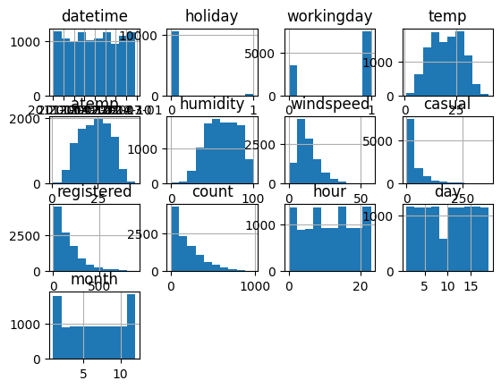

```python
# View histogram of all features again now with the hour feature
train.hist()
```

## Step 5: Rerun the model with the same settings as before, just with more features

```python
train_mf = train.drop(["casual", "registered"], axis=1)

predictor_new_features = TabularPredictor(label="count", eval_metric="rmse", problem_type="regression").fit(
    train_data=train_mf, time_limit=600, presets="best_quality"
)
```

```
No path specified. Models will be saved in: "AutogluonModels/ag-20240423_142329"
Presets specified: ['best_quality']
Setting dynamic_stacking from 'auto' to True. Reason: Enable dynamic_stacking when use_bag_holdout is disabled. (use_bag_holdout=False)
Stack configuration (auto_stack=True): num_stack_levels=1, num_bag_folds=8, num_bag_sets=1
Dynamic stacking is enabled (dynamic_stacking=True). AutoGluon will try to determine whether the input data is affected by stacked overfitting and enable or disable stacking as a consequence.
Detecting stacked overfitting by sub-fitting AutoGluon on the input data. That is, copies of AutoGluon will be sub-fit on subset(s) of the data. Then, the holdout validation data is used to detect stacked overfitting.
Sub-fit(s) time limit is: 600 seconds.
Starting holdout-based sub-fit for dynamic stacking. Context path is: AutogluonModels/ag-20240423_142329/ds_sub_fit/sub_fit_ho.
Running the sub-fit in a ray process to avoid memory leakage.
Spend 192 seconds for the sub-fit(s) during dynamic stacking.
Time left for full fit of AutoGluon: 408 seconds.
Starting full fit now with num_stack_levels 1.
Beginning AutoGluon training ... Time limit = 408s
AutoGluon will save models to "AutogluonModels/ag-20240423_142329"
=================== System Info ===================
AutoGluon Version:  1.1.0
Python Version:     3.10.12
Operating System:   Linux
Platform Machine:   x86_64
Platform Version:   #1 SMP PREEMPT_DYNAMIC Sat Nov 18 15:31:17 UTC 2023
CPU Count:          2
Memory Avail:       9.70 GB / 12.67 GB (76.6%)
Disk Space Avail:   74.91 GB / 107.72 GB (69.5%)
===================================================
Train Data Rows:    10886
Train Data Columns: 12
Label Column:       count
Problem Type:       regression
Preprocessing data ...
Using Feature Generators to preprocess the data ...
Fitting AutoMLPipelineFeatureGenerator...
	Available Memory:                    9936.40 MB
	Train Data (Original)  Memory Usage: 0.73 MB (0.0% of available memory)
	Inferring data type of each feature based on column values. Set feature_metadata_in to manually specify special dtypes of the features.
	Stage 1 Generators:
		Fitting AsTypeFeatureGenerator...
			Note: Converting 2 features to boolean dtype as they only contain 2 unique values.
	Stage 2 Generators:
		Fitting FillNaFeatureGenerator...
	Stage 3 Generators:
```

[output cut: 83 more lines]

```
Fitting model: RandomForestMSE_BAG_L2 ... Training model for up to 51.68s of the 51.61s of remaining time.
	-31.7326	 = Validation score   (-root_mean_squared_error)
	45.84s	 = Training   runtime
	0.68s	 = Validation runtime
Fitting model: CatBoost_BAG_L2 ... Training model for up to 4.35s of the 4.28s of remaining time.
	Fitting 8 child models (S1F1 - S1F8) | Fitting with ParallelLocalFoldFittingStrategy (2 workers, per: cpus=1, gpus=0, memory=0.13%)
	Time limit exceeded... Skipping CatBoost_BAG_L2.
2024-04-23 14:33:31,846	ERROR worker.py:406 -- Unhandled error (suppress with 'RAY_IGNORE_UNHANDLED_ERRORS=1'): The worker died unexpectedly while executing this task. Check python-core-worker-*.log files for more information.
Fitting model: WeightedEnsemble_L3 ... Training model for up to 360.0s of the -2.48s of remaining time.
	Ensemble Weights: {'LightGBM_BAG_L2': 0.5, 'LightGBMXT_BAG_L2': 0.333, 'RandomForestMSE_BAG_L2': 0.125, 'CatBoost_BAG_L1': 0.042}
	-30.4278	 = Validation score   (-root_mean_squared_error)
	0.06s	 = Training   runtime
	0.0s	 = Validation runtime
AutoGluon training complete, total runtime = 410.62s ... Best model: "WeightedEnsemble_L3"
TabularPredictor saved. To load, use: predictor = TabularPredictor.load("AutogluonModels/ag-20240423_142329")
```

```python
predictor_new_features.fit_summary()
```

```
*** Summary of fit() ***
Estimated performance of each model:
                     model   score_val              eval_metric  pred_time_val    fit_time  pred_time_val_marginal  fit_time_marginal  stack_level  can_infer  fit_order
0      WeightedEnsemble_L3  -30.427816  root_mean_squared_error      28.507921  375.296521                0.001216           0.060115            3       True         11
1          LightGBM_BAG_L2  -30.758454  root_mean_squared_error      25.988699  288.922876                0.495484          32.298829            2       True          9
2        LightGBMXT_BAG_L2  -31.141101  root_mean_squared_error      27.329164  297.100143                1.835949          40.476097            2       True          8
3   RandomForestMSE_BAG_L2  -31.732551  root_mean_squared_error      26.175272  302.461481                0.682057          45.837434            2       True         10
4      WeightedEnsemble_L2  -32.408237  root_mean_squared_error      25.428244  256.621492                0.001257           0.049195            2       True          7
5          LightGBM_BAG_L1  -33.916920  root_mean_squared_error       3.790118   53.642365                3.790118          53.642365            1       True          4
6        LightGBMXT_BAG_L1  -34.519031  root_mean_squared_error      20.778235  111.328447               20.778235         111.328447            1       True          3
7          CatBoost_BAG_L1  -36.811988  root_mean_squared_error       0.166340   71.300546                0.166340          71.300546            1       True          6
8   RandomForestMSE_BAG_L1  -38.408907  root_mean_squared_error       0.625659   20.254402                0.625659          20.254402            1       True          5
9    KNeighborsDist_BAG_L1  -84.125061  root_mean_squared_error       0.066633    0.046538                0.066633           0.046538            1       True          2
10   KNeighborsUnif_BAG_L1 -101.546199  root_mean_squared_error       0.066229    0.051749                0.066229           0.051749            1       True          1
Number of models trained: 11
Types of models trained:
{'StackerEnsembleModel_CatBoost', 'StackerEnsembleModel_KNN', 'StackerEnsembleModel_RF', 'StackerEnsembleModel_LGB', 'WeightedEnsembleModel'}
Bagging used: True  (with 8 folds)
Multi-layer stack-ensembling used: True  (with 3 levels)
Feature Metadata (Processed):
(raw dtype, special dtypes):
('category', [])             : 2 | ['season', 'weather']
('float', [])                : 3 | ['temp', 'atemp', 'windspeed']
('int', [])                  : 4 | ['humidity', 'hour', 'day', 'month']
('int', ['bool'])            : 2 | ['holiday', 'workingday']
('int', ['datetime_as_int']) : 3 | ['datetime', 'datetime.year', 'datetime.dayofweek']
*** End of fit() summary ***
```

[output not shown]

[output cut: 89 more lines]

```
 9        0.066633    0.046538                0.066633           0.046538
 10       0.066229    0.051749                0.066229           0.051749

     stack_level  can_infer  fit_order
 0             3       True         11
 1             2       True          9
 2             2       True          8
 3             2       True         10
 4             2       True          7
 5             1       True          4
 6             1       True          3
 7             1       True          6
 8             1       True          5
 9             1       True          2
 10            1       True          1  }
```

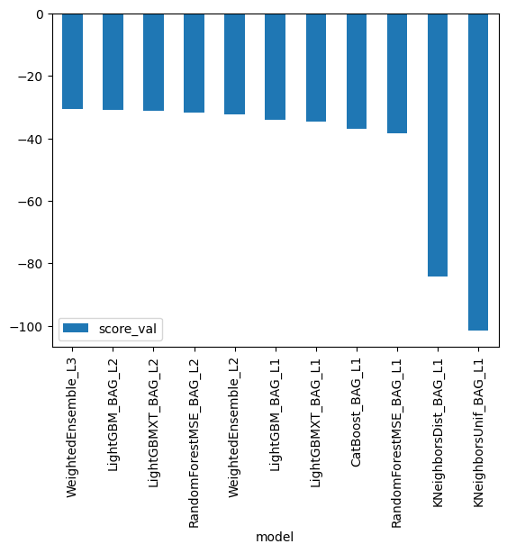

```python
# compare models
predictor_new_features.leaderboard(silent=True).plot(kind="bar", x = "model", y="score_val")
```

```python
# Remember to set all negative values to zero
predictions_new_features = predictor_new_features.predict(test)

predictions_new_features[predictions_new_features <0] = 0
predictions_new_features.describe()
```

```
count    6493.000000
mean      162.904922
std       144.721817
min         2.125134
25%        49.239899
50%       125.542427
75%       235.245163
max       810.398254
Name: count, dtype: float64
```

```python
# Same submitting predictions
submission_new_features = pd.read_csv("sampleSubmission.csv")
submission_new_features["count"] = predictions_new_features
submission_new_features.to_csv("submission_new_features.csv", index=False)
```

```python
!kaggle competitions submit -c bike-sharing-demand -f submission_new_features.csv -m "new features second run"
```

```python
!kaggle competitions submissions -c bike-sharing-demand | tail -n +1 | head -n 10
```

[output not shown]